# 8º Workshop - O que podemos descobrir com a taxa de mortalidade nos Hospitais americanos?

## Autor

Nome: Enilton Angelim

## Questões

1. Quais são os melhores Hospitais dos E.U.A?
2. Quais são os piores Hospitais dos E.U.A?

## Variáveis Quantitativas

Será considerado a taxa de mortalidade dos itens:

1. Insuficiência Cardíaca - A taxa é ajustada ao risco (Porcentagem) para cada hospital;
2. Ataque cardíaco - A taxa é ajustada ao risco (Porcentagem) para cada hospital;
3. Pneumonia - A taxa é ajustada ao risco (Porcentagem) para cada hospital;

## Variáveis Qualitativas

Com a finalidade de demonstração, usarei as variáveis:

1. Nome do Hospital
2. Sigla do Estado Americano

## Método de elaboração da resposta

O método *exploratório* será usado para sintetizar a medição publicada pela *U.S. Department of Health and Human Services*. Assim, podemos descobri tendências, ou gerar ideias, ou gerar hipóteses durante a análise dos dados. Nesse método podemos realizar descobertas, mas raramente confirmá-las.

## Sobre os dados

Os dados foram coletados no site do governo Americano *U.S. Department of Health and Human Services*, sendo a média de mortalidade ajustada ao período de 30 dias para ataque cardíaco, insuficiência cardíaca. Os dados sobre a pneumonia é produzido a partir dos pedidos do `Medicare` e dos dados de inscrição.

| Dados | Descrição |
| --- | --- |
| outcome-of-care-measures.csv | Contém informações sobre a taxa de mortalidade, considerando o período de 30 dias para mais de 4.000 Hospitais |

### Visualização da Taxa de Mortalidade por **ataque do coração** e **insuficiência cardíaca**.

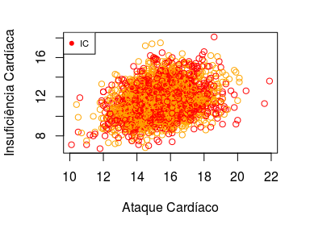

```r
require(ggplot2)
DATA_REPOSITORY_OUTCOME_MEASURE='/home/enilton/workspace/data-science/datasets/hospital_quality/outcome-of-care-measures.csv'
outcome_measure <-read.csv(DATA_REPOSITORY_OUTCOME_MEASURE, colClasses = 'character')
outcome_measure[, 11] <- suppressWarnings(
      as.numeric(outcome_measure[, 11])
    )
outcome_measure[, 17] <- suppressWarnings(
      as.numeric(outcome_measure[, 17])
    )
outcome_measure <- na.omit(outcome_measure)
plot(outcome_measure$Hospital.30.Day.Death..Mortality..Rates.from.Heart.Attack, outcome_measure$Hospital.30.Day.Death..Mortality..Rates.from.Heart.Failure, ylab = 'Insuficiência Cardíaca', xlab = 'Ataque Cardíaco', col = c('red','orange') )
legend(
  x ="topleft",
  legend = paste("IC", levels(c('red','orange'))), # for readability of legend
  col = c('red','orange'),
  pch = 19, # same as pch=20, just smaller
  cex = .7 # scale the legend to look attractively sized
)
```

```r
summary(outcome_measure$Hospital.30.Day.Death..Mortality..Rates.from.Heart.Attack, outcome_measure$Hospital.30.Day.Death..Mortality..Rates.from.Heart.Failure)
```

```
   Min. 1st Qu.  Median    Mean 3rd Qu.    Max.
  10.10   14.50   15.40   15.45   16.40   21.90
```

### Visualização da Taxa de Mortalidade por **pneumonia**.

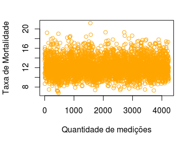

```r
DATA_REPOSITORY_OUTCOME_MEASURE='/home/enilton/workspace/data-science/datasets/hospital_quality/outcome-of-care-measures.csv'
outcome_measure <-read.csv(DATA_REPOSITORY_OUTCOME_MEASURE, colClasses = 'character')
outcome_measure[, 23] <- suppressWarnings(
      as.numeric(outcome_measure[, 23])
    )
outcome_measure <- na.omit(outcome_measure)
plot(outcome_measure$Hospital.30.Day.Death..Mortality..Rates.from.Pneumonia, ylab = 'Taxa de Mortalidade', xlab = 'Quantidade de medições', col = c('orange'))
```

```r
summary(outcome_measure$Hospital.30.Day.Death..Mortality..Rates.from.Pneumonia)
```

```
   Min. 1st Qu.  Median    Mean 3rd Qu.    Max.
    6.8    10.9    11.9    12.1    13.1    21.2
```

## Resposta das Questões

### Qual o melhor Hospital em cada Estado dos E.U.A? (rank estadual)

1. Considerando os melhores resultados para **Ataque Cardíaco**

```r
source('~/workspace/data-science/tools/hospital/rankall.R')
rankall("heart attack", 'best')
```

|  | hospital | state |
| --- | --- | --- |
| AK | PROVIDENCE ALASKA MEDICAL CENTER | AK |
| AL | CRESTWOOD MEDICAL CENTER | AL |
| AR | ARKANSAS HEART HOSPITAL | AR |
| AZ | MAYO CLINIC HOSPITAL | AZ |
| CA | GLENDALE ADVENTIST MEDICAL CENTER | CA |
| CO | ST MARYS HOSPITAL AND MEDICAL CENTER | CO |
| CT | WATERBURY HOSPITAL | CT |
| DC | PROVIDENCE HOSPITAL | DC |
| DE | BAYHEALTH - KENT GENERAL HOSPITAL | DE |
| FL | MOUNT SINAI MEDICAL CENTER | FL |

[output cut: 44 more lines]

2. Considerando os melhores resultados para **Insuficiência Cardíaca**

```r
source('~/workspace/data-science/tools/hospital/rankall.R')
rankall("heart failure", 'best')
```

|  | hospital | state |
| --- | --- | --- |
| AK | SOUTH PENINSULA HOSPITAL | AK |
| AL | GEORGE H. LANIER MEMORIAL HOSPITAL | AL |
| AR | VA CENTRAL AR. VETERANS HEALTHCARE SYSTEM LR | AR |
| AZ | BANNER GOOD SAMARITAN MEDICAL CENTER | AZ |
| CA | CENTINELA HOSPITAL MEDICAL CENTER | CA |
| CO | PARKER ADVENTIST HOSPITAL | CO |
| CT | YALE-NEW HAVEN HOSPITAL | CT |
| DC | PROVIDENCE HOSPITAL | DC |
| DE | BAYHEALTH - KENT GENERAL HOSPITAL | DE |
| FL | FLORIDA HOSPITAL HEARTLAND MEDICAL CENTER | FL |

[output cut: 44 more lines]

3. Considerando os melhores resultados para **Pneumonia**

```r
source('~/workspace/data-science/tools/hospital/rankall.R')
rankall("pneumonia", 'best')
```

|  | hospital | state |
| --- | --- | --- |
| AK | YUKON KUSKOKWIM DELTA REG HOSPITAL | AK |
| AL | MARSHALL MEDICAL CENTER NORTH | AL |
| AR | STONE COUNTY MEDICAL CENTER | AR |
| AZ | MAYO CLINIC HOSPITAL | AZ |
| CA | CEDARS-SINAI MEDICAL CENTER | CA |
| CO | EXEMPLA LUTHERAN MEDICAL CENTER | CO |
| CT | SAINT MARYS HOSPITAL | CT |
| DC | WASHINGTON HOSPITAL CENTER | DC |
| DE | BEEBE MEDICAL CENTER | DE |
| FL | MOUNT SINAI MEDICAL CENTER | FL |

[output cut: 44 more lines]

### Qual o pior Hospital em cada Estado dos E.U.A? (rank estadual)

1. Considerando os piores resultados para **Ataque Cardíaco**

```r
source('~/workspace/data-science/tools/hospital/rankall.R')
rankall("heart attack", 'worst')
```

|  | hospital | state |
| --- | --- | --- |
| AK | MAT-SU REGIONAL MEDICAL CENTER | AK |
| AL | HELEN KELLER MEMORIAL HOSPITAL | AL |
| AR | MEDICAL CENTER SOUTH ARKANSAS | AR |
| AZ | VERDE VALLEY MEDICAL CENTER | AZ |
| CA | METHODIST HOSPITAL OF SACRAMENTO | CA |
| CO | NORTH SUBURBAN MEDICAL CENTER | CO |
| CT | JOHNSON MEMORIAL HOSPITAL | CT |
| DC | HOWARD UNIVERSITY HOSPITAL | DC |
| DE | ST FRANCIS HEALTHCARE | DE |
| FL | PALMETTO GENERAL HOSPITAL | FL |

[output cut: 44 more lines]

2. Considerando os piores resultados para **Insuficiência Cardíaca**

```r
source('~/workspace/data-science/tools/hospital/rankall.R')
rankall("heart failure", 'worst')
```

|  | hospital | state |
| --- | --- | --- |
| AK | FAIRBANKS MEMORIAL HOSPITAL | AK |
| AL | DEKALB REGIONAL MEDICAL CENTER | AL |
| AR | NEA BAPTIST MEMORIAL HOSPITAL | AR |
| AZ | MT GRAHAM REGIONAL MEDICAL CENTER | AZ |
| CA | CLOVIS COMMUNITY MEDICAL CENTER | CA |
| CO | CENTURA HEALTH-ST THOMAS MORE HOSPITAL | CO |
| CT | MANCHESTER MEMORIAL HOSPITAL | CT |
| DC | GEORGETOWN UNIVERSITY HOSPITAL | DC |
| DE | BEEBE MEDICAL CENTER | DE |
| FL | MANATEE MEMORIAL HOSPITAL | FL |

[output cut: 44 more lines]

3. Considerando os piores resultados para **Pneumonia**

```r
source('~/workspace/data-science/tools/hospital/rankall.R')
rankall("pneumonia", 'worst')
```

|  | hospital | state |
| --- | --- | --- |
| AK | ALASKA NATIVE MEDICAL CENTER | AK |
| AL | JACKSONVILLE MEDICAL CENTER | AL |
| AR | RIVER VALLEY MEDICAL CENTER | AR |
| AZ | HAVASU REGIONAL MEDICAL CENTER | AZ |
| CA | DELANO REGIONAL MEDICAL CENTER | CA |
| CO | ST MARYS HOSPITAL AND MEDICAL CENTER | CO |
| CT | MILFORD HOSPITAL, INC | CT |
| DC | GEORGETOWN UNIVERSITY HOSPITAL | DC |
| DE | CHRISTIANA CARE HEALTH SERVICES, INC. | DE |
| FL | SEVEN RIVERS REGIONAL MEDICAL CENTER | FL |

[output cut: 44 more lines]

## Scripts

1. Best.R

```r
# Autor: Enilton Angelim
library(dplyr)
source('~/workspace/data-science/tools/hospital/helper.R')
## Const
DATA_REPOSITORY_OUTCOME_MEASURE='/home/enilton/workspace/data-science/datasets/hospital_quality/outcome-of-care-measures.csv'
best <- function (state, outcome) {
  ## Read outcome data
  outcome_measure <-read.csv(DATA_REPOSITORY_OUTCOME_MEASURE, colClasses = 'character')
  ## Check  that state and outcome are valid
  outcome <- outcome_helper(state, outcome)

  ## Return hospital name in that state with lowest 30-day death
  ## rate
  ## Outcome coercion
  outcome_measure[, outcome$indice] <- suppressWarnings(
      as.numeric(outcome_measure[, outcome$indice])
    )
  ## Omit na values
  outcome_measure <- na.omit(outcome_measure)
  ## Select columns by regex
  data <- select(outcome_measure, matches(outcome$match, ignore.case = TRUE))
  ## Filter State
  data <- filter(data, data$State == state)
  ## Filter hospital with lowest mortality
  data <- filter(data, data[3] == min(data[3]))
  ## Order by Hospital name
  data <- data[order(data$Hospital.Name),]
  return(data$Hospital.Name)
}
```

2. Helper.R

```r
#Autor: Enilton Angelim
outcome_helper <- function (state = 'TX', outcome = NULL) {

  if(! state %in% outcome_measure$State){
    stop("State invalid!")
  }

  if ( outcome == "heart attack" ) {
    return(list(indice = 11, match = "^(Sta|Hos.*death.*rates.*heart.attack|Hos.*name)"))
  } else  if ( outcome == "heart failure" ) {
    return(list(indice = 17, match = "^(Sta|Hos.*death.*rates.*heart.failure|Hos.*name)"))
  } else  if ( outcome == "pneumonia" ) {
    return(list(indice = 23, match = "^(Sta|Hospital.*death.*rates.*pneumonia|Hos.*name)"))
  } else {
    stop('Outcome invalid! Use: "heart attack", "heart failure" or "pneumonia')
  }

}
```

3. rankHospital.R

```r
#Autor: Enilton Angelim
library(dplyr)
source('~/workspace/data-science/tools/hospital/helper.R')

## Const
DATA_REPOSITORY_OUTCOME_MEASURE='/home/enilton/workspace/data-science/datasets/hospital_quality/outcome-of-care-measures.csv'

rankhospital <- function (state, outcome, num = "best") {

  ## Read outcome data
  outcome_measure <-read.csv(DATA_REPOSITORY_OUTCOME_MEASURE,
                             colClasses = 'character')

  ## Check that state and outcome are valid
  outcome <- outcome_helper(state, outcome)

  ## Return hospital name in that state with the given rank
  ## 30-day death rate
  outcome_measure[, outcome$indice] <- suppressWarnings(
    as.numeric(outcome_measure[, outcome$indice])
  )

  ## Omit na values
  outcome_measure <- na.omit(outcome_measure)
  ## Select columns by regex
  data <- select(outcome_measure, matches(outcome$match, ignore.case = TRUE))
  ## Filter State and order by Rate and then Hospital Name
  data <- filter(data, data$State == state)
  data <- data[order( data[3], data$Hospital.Name), ]
  ## Rank table
  rank <- data.frame( Hospital.Name = data$Hospital.Name, Rate = data[,3],
                      Rank = 1:nrow(data), row.names = NULL )

  if ( num == 'best' ) {
    num <- 1
  } else if ( num == 'worst' ) {
    num <- nrow(rank)
  } else if (num > nrow(rank)) {
    return(NA)
  } else if (!is.numeric(num)) {
    return(NA)
  }

  return(rank$Hospital.Name[ rank$Rank == num ])

}
```

4. rankAll.R

```r
#Autor: Enilton Angelim
library(dplyr)
source('~/workspace/data-science/tools/hospital/helper.R')

## Const
DATA_REPOSITORY_OUTCOME_MEASURE='/home/enilton/workspace/data-science/datasets/hospital_quality/outcome-of-care-measures.csv'

# Write a function called rankall that takes two arguments: an outcome name (outcome) and a hospital ranking
# (num). The function reads the outcome-of-care-measures.csv file and returns a 2-column data frame
# containing the hospital in each state that has the ranking specified in num. For example the function call
# rankall("heart attack", "best") would return a data frame containing the names of the hospitals that
# are the best in their respective states for 30-day heart attack death rates. The function should return a value
# for every state (some may be NA). The first column in the data frame is named hospital, which contains
# the hospital name, and the second column is named state, which contains the 2-character abbreviation for
# the state name. Hospitals that do not have data on a particular outcome should be excluded from the set of
# hospitals when deciding the rankings.
# Handling ties. The rankall function should handle ties in the 30-day mortality rates in the same way
# that the rankhospital function handles ties.

rankall <- function(outcome, num = "best") {
  ## Read outcome data
  outcome_measure <-read.csv(DATA_REPOSITORY_OUTCOME_MEASURE,
                             colClasses = 'character')
  ## Check that num and outcome are valid
  outcome <- outcome_helper(outcome=outcome)
  ## Return hospital name in that state with the given rank
  ## 30-day death rate
  outcome_measure[, outcome$indice] <- suppressWarnings(
    as.numeric(outcome_measure[, outcome$indice])
  )
  ## Omit na values
  outcome_measure <- na.omit(outcome_measure)
  ## For each state, find the hospital of the given rank
  ## Select columns by regex
  data <- select(outcome_measure, matches(outcome$match, ignore.case = TRUE))
  ## Filter State and order by Rate and then Hospital Name
  data.states <- unique(data$State)
  data.states <- data.states[order(data.states)]
  data <- data[order( data[3], data$Hospital.Name), ]
  ## Rank table
  rank <- data.frame( hospital = FALSE, state = data.states,
                      row.names = data.states )
  rank$hospital <- sapply(data.states, function(s){
    data.state <- filter(data, data$State == s)
    num <- ifelse(num == 'best', 1, num)
    num <- ifelse(num == 'worst', nrow(data.state) , num)
    return(data.state[num,1])
  })
  ## Return a data frame with the hospital names and the
  ## (abbreviated) state name
  return(rank)
}
```